Walter Ac-Pangan

R NotesSAS NotesStata NotesTeaching

# Py Notes for AGECON: Basics and Fundamentals

Walter Ac-Pangan, Ph.D. · August 2025

These notes introduce Python for agricultural economics, following the same steps as the R Notes for AGECON. The examples are intentionally basic: run each cell in order and compare the results with the outputs shown here.

## 1 Introduction to Python

Python is a free, open-source programming language that is widely used for data analysis, statistics, machine learning, and visualization. It is a general-purpose language, so the same skills you learn here will help you clean data, run regressions, build maps, and automate everyday tasks.

Python code is usually written in **Jupyter notebooks**: documents that mix text, code, and results, just like this one. Each block of code is called a **cell**, and you run cells one at a time to see their results right below them.

### 1.1 Installation

You have three easy options:

1. **Google Colab (no installation).** Go to https://colab.research.google.com, sign in with a Google account, and create a new notebook. Most packages used here are already installed.
2. **Anaconda.** Download it from https://www.anaconda.com/download. It installs Python, Jupyter, and the most common data packages in one step.
3. **VS Code.** Install Python from https://www.python.org/downloads and the free editor from https://code.visualstudio.com, then add the Python and Jupyter extensions.

### 1.2 The Notebook Interface

A notebook has two kinds of cells:

1. **Code cells**, where you write and run Python code.
2. **Text (Markdown) cells**, where you write notes and explanations.

To run a cell, click inside it and press `Shift + Enter`, or click the play button next to the cell. The result appears below the cell. Cells share the same memory, so a variable created in one cell can be used in the next ones.

## 2 The Basics

### 2.1 Executing Code & Variable Creation

Below are a few lines of code. Type them into a code cell or copy and paste them from this document, then run the cell.

```
w = 10  # assign the value 10 to the variable "w"
x = 20  # assign the value 20 to the variable "x"
y = 30
```

You have just assigned values to the variables `w`, `x`, and `y`. Unlike R, Python has a single assignment operator: `=`. Running the cell does not print anything; it only stores the values in memory.

Now run:

```
print(x, y)  # print "x" and "y"
```

```
20 30
```

In a notebook, the value of the **last line** of a cell is also displayed automatically:

```
x
```

```
20
```

### 2.2 Python is Case Sensitive

Now run:

```
x = 5   # re-assign a new value to variable "x"
a = 10
A = 20
print(x, a, A)  # print "x", "a", and "A"
```

```
5 10 20
```

You have just seen that you can re-assign a new value to a variable. Be mindful of this as your scripts grow and include many variables.

Also, Python is case sensitive: `a` above equals `10` and `A` equals `20`.

Putting `#` in front of a line prevents it from being executed. These **comments** are useful to leave yourself notes and reminders.

### 2.3 Missing Values

Python has two common ways to represent a missing value: `None` (plain Python) and `np.nan` ("not a number", from the NumPy package). In data analysis you will mostly see `np.nan`. Keep in mind that a missing value is **not** equal to zero.

```
import numpy as np  # NumPy is the core package for numbers and arrays

x = np.nan
x
```

```
nan
```

Math operations with a missing value return a missing value:

```
print(x + 1)
print(np.sum([1, x, 3]))
```

```
nan
nan
```

However, NumPy has versions of its functions that ignore missing values, similar to `na.rm = TRUE` in R:

```
print(np.nansum([1, x, 3]))  # sum, ignoring the missing value
```

```
4.0
```

### 2.4 Calculator and Math Functions

We will pick up the pace now. Comments are provided throughout to explain each function. Let us set `x = 3` and `y = 7`.

```
x = 3  # re-assign a new value to variable "x"
y = 7
print(x, y)
```

```
3 7
```

The lines below demonstrate basic mathematical operations. The `math` module, included with Python, provides functions such as square roots and logarithms.

```
import math

print(x + y)            # addition
print(x - y)            # subtraction
print(x * y)            # multiplication
print(x / y)            # division
print(x * y * 1 - y)
print(x * y * (1 - y))  # use parentheses to control the order of operations

print(x ** 2)           # exponent (R uses x^2)
print(math.sqrt(x))     # square root

print(round(x / y, 3))  # rounds x/y to 3 decimal places

print(math.floor(x / y))  # largest integer less than or equal to x/y
print(math.ceil(x / y))   # smallest integer greater than or equal to x/y

print(abs(x - y))       # absolute value
print(math.log(x))      # natural log (base e)
print(math.log10(x))    # log base 10
```

```
10
-4
21
0.42857142857142855
14
-126
9
1.7320508075688772
0.429
0
1
4
1.0986122886681098
0.47712125471966244
```

Logical operators return `True` or `False`:

```
print(x == y)               # is "x" equal to "y"?
print(x != y)               # is "x" not equal to "y"?
print(x < 10)               # is "x" less than 10?
print(x <= 2)               # is "x" less than or equal to 2?
print(x < 20 and y >= 50)   # is "x" less than 20 AND "y" at least 50?
print(x < 20 or y >= 50)    # is "x" less than 20 OR "y" at least 50?

z = [1, 2, 3, 4]            # a list of numbers
print(z)
print(x in z)               # is "x" contained in "z"?
print(x not in z)           # is "x" not contained in "z"?
print(5 in z)               # is 5 contained in "z"?
```

```
False
True
True
False
False
True
[1, 2, 3, 4]
True
False
False
```

If-else statements:

```
# returns x + y if x equals 100, otherwise returns None (missing)
result1 = x + y if x == 100 else None
# returns x + y if x is less than 100, otherwise returns None
result2 = x + y if x < 100 else None
print(result1, result2)

# The same idea written as a full if-else block
if x < 100:
    print("x is less than 100")
else:
    print("x is 100 or more")
```

```
None 10
x is less than 100
```

Two more operators are very useful. **Floor division** `//` returns the whole-number part of a division, and the **modulus** `%` returns the remainder:

```
total_bushels = 1250   # bushels harvested
truck_capacity = 400   # bushels per truck

print(total_bushels // truck_capacity)  # full truckloads: 3
print(total_bushels % truck_capacity)   # bushels left over: 50
```

```
3
50
```

### Economics Examples

Let us put these operations to work with a few everyday calculations in agricultural economics.

**Unit conversion.** Corn is traded in bushels, but international statistics use metric tons. One bushel of corn weighs 56 pounds, and one pound equals 0.45359237 kg:

```
bushels = 10000
kg_per_bushel = 56 * 0.45359237           # 25.4 kg per bushel of corn
metric_tons = bushels * kg_per_bushel / 1000
print(round(metric_tons, 2), "metric tons")
```

```
254.01 metric tons
```

**Revenue, cost, and profit** for a 500-acre corn farm:

```
acres = 500
yield_bu_acre = 180      # bushels per acre
price = 4.25             # dollars per bushel
cost_per_acre = 690      # dollars per acre

revenue = acres * yield_bu_acre * price
total_cost = acres * cost_per_acre
profit = revenue - total_cost
margin = profit / revenue * 100

print("Revenue:", revenue)
print("Total cost:", total_cost)
print("Profit:", profit)
print("Profit margin (%):", round(margin, 1))
```

```
Revenue: 382500.0
Total cost: 345000
Profit: 37500.0
Profit margin (%): 9.8
```

**Break-even price**: the price at which revenue just covers cost.

```
break_even_price = cost_per_acre / yield_bu_acre
print("Break-even price ($/bu):", round(break_even_price, 2))
```

```
Break-even price ($/bu): 3.83
```

**Percent change** in the price of soybeans from one year to the next:

```
price_2023 = 13.20
price_2024 = 10.90
pct_change = (price_2024 - price_2023) / price_2023 * 100
print("Percent change:", round(pct_change, 1), "%")
```

```
Percent change: -17.4 %
```

**Compound interest**: the future value of $10,000 saved for 5 years at 4% interest per year, using $FV = PV(1 + r)^t$:

```
PV = 10000   # present value
r = 0.04     # annual interest rate
t = 5        # years
FV = PV * (1 + r) ** t
print("Future value:", round(FV, 2))
```

```
Future value: 12166.53
```

### 2.5 Understanding Variables in Python

Python uses several data types that you will encounter often. The `type()` function returns the type of any variable.

1. **Integer** (`int`): whole numbers.

```
a = 3
print(a)
type(a)
```

```
3
```

```
<class 'int'>
```

1. **Float** (`float`): numbers with decimals. Converting a float to an integer with `int()` drops the decimal part.

```
b = 5.6
print(b, type(b))

b2 = int(5.6)  # converts 5.6 to an integer
print(b2, type(b2))  # notice the decimal part is dropped

b3 = "6.7"  # quotation marks make this text, not a number
print(b3, type(b3))
```

```
5.6 <class 'float'>
5 <class 'int'>
6.7 <class 'str'>
```

1. **String** (`str`): text. You cannot do math with text, even if it looks like a number. The cell below shows the error you get when you try:

```
c = "WillieTheWildcat"
print(c, type(c))

d = str(3)  # "3" is now text
print(d, type(d))
d + 1       # this produces an error
```

```
WillieTheWildcat <class 'str'>
3 <class 'str'>
```

```
TypeError: can only concatenate str (not "int") to str
```

To fix it, convert the text back to a number first:

```
int(d) + 1
```

```
4
```

1. **Boolean** (`bool`): `True` or `False`.

```
l_t = True
l_f = False
type(l_t)
```

```
<class 'bool'>
```

1. **Categorical**: a variable with a fixed set of groups, similar to a factor in R. Categories come from the pandas package, which we use for data tables.

```
import pandas as pd  # pandas is the main package for data tables

US_state = pd.Categorical(["Kansas", "Iowa", "Nebraska", "Texas"])
US_state
```

```
['Kansas', 'Iowa', 'Nebraska', 'Texas']
Categories (4, str): ['Iowa', 'Kansas', 'Nebraska', 'Texas']
```

1. **Dates and times**.

```
date_var = pd.Timestamp("2024-08-12")
time_var = pd.Timestamp("2024-08-12 12:34:56")

print(date_var.date(), type(date_var))
print(time_var)
print(date_var.year, date_var.month, date_var.day)  # extract parts of a date
```

```
2024-08-12 <class 'pandas.Timestamp'>
2024-08-12 12:34:56
2024 8 12
```

### Converting Between Types

Data often arrives as text. For example, a price scraped from a website may look like `"$4.25"`. To do math with it, remove the dollar sign and convert it to a float:

```
price_text = "$4.25"
price = float(price_text.replace("$", ""))  # remove "$", then convert to a number
print(price * 2)

quantity_text = "1,250"
quantity = int(quantity_text.replace(",", ""))  # remove the comma
print(quantity + 1)
```

```
8.5
1251
```

### Formatting Numbers with f-strings

An **f-string** (a string with `f` before the quotes) lets you place variables inside text and control how numbers are displayed:

```
revenue = 382500
rate = 0.0475

print(f"Revenue: ${revenue:,.2f}")    # comma separators, 2 decimals
print(f"Interest rate: {rate:.2%}")   # shown as a percentage
print(f"Revenue in millions: {revenue / 1e6:.2f} M")
```

```
Revenue: $382,500.00
Interest rate: 4.75%
Revenue in millions: 0.38 M
```

### Working with Dates

Dates are useful for questions like "how many days until harvest?" or "when does this loan mature?":

```
planting = pd.Timestamp("2024-04-25")
harvest = pd.Timestamp("2024-10-05")
season_length = harvest - planting
print("Days from planting to harvest:", season_length.days)

loan_start = pd.Timestamp("2024-03-01")
maturity = loan_start + pd.DateOffset(months=18)   # an 18-month operating loan
print("Loan matures on:", maturity.date())

months = pd.date_range("2024-01-01", periods=6, freq="MS")  # first day of each month
print(months.strftime("%b %Y").tolist())
```

```
Days from planting to harvest: 163
Loan matures on: 2025-09-01
['Jan 2024', 'Feb 2024', 'Mar 2024', 'Apr 2024', 'May 2024', 'Jun 2024']
```

### 2.6 Delete Objects from Memory

Use `del` to remove a variable. After deleting it, Python no longer knows the name.

```
x = 5
print(x)

X = "My name is Willie"  # assign a string to the variable "X"
print(X)

del x  # remove "x" from memory
# print(x)  # this would now give an error: name 'x' is not defined
```

```
5
My name is Willie
```

### 2.7 Install and Import Packages

Packages add functions to Python. You **install** a package once, then **import** it in every notebook where you use it. To install packages, run the line below once (remove the `#` first). In Google Colab most of them are already installed.

```
# !pip install pandas numpy matplotlib seaborn statsmodels plotly openpyxl

import numpy as np               # arrays and math
import pandas as pd              # data tables (like data frames in R)
import matplotlib.pyplot as plt  # plots
```

### Different Ways to Import

There are three common ways to import, and you will see all of them in other people's code:

```
import math                 # use as math.sqrt()
import numpy as np          # import with a short nickname (alias)
from math import sqrt, exp  # import only the functions you need

print(math.sqrt(16), np.sqrt(16), sqrt(16))
print(exp(1))  # Euler's number e
```

```
4.0 4.0 4.0
2.718281828459045
```

## 3 Fundamentals

This section covers the building blocks you will use in almost every program: storing data in different structures, making decisions, repeating tasks, and writing your own functions. All examples use simple economics problems.

### 3.1 Data Structures: Lists, Tuples, Dictionaries, and Sets

Python has four built-in ways to store collections of values:

| Structure | Example | Ordered? | Can change? | Typical use |
| --- | --- | --- | --- | --- |
| List | `[4.25, 4.10, 4.40]` | Yes | Yes | a series of prices |
| Tuple | `(39.19, -96.58)` | Yes | No | fixed values, such as coordinates |
| Dictionary | `{"corn": 4.25}` | Yes | Yes | look up a value by its name |
| Set | `{"Mexico", "Japan"}` | No | Yes | unique items, no duplicates |

**Lists** keep values in order and can be changed:

```
corn_prices = [4.25, 4.10, 4.40, 4.55]  # weekly prices, $/bu
corn_prices.append(4.60)                # add a new week
print(corn_prices)
print("Weeks recorded:", len(corn_prices))
print("Average price:", round(sum(corn_prices) / len(corn_prices), 3))
```

```
[4.25, 4.1, 4.4, 4.55, 4.6]
Weeks recorded: 5
Average price: 4.38
```

**Tuples** are like lists but cannot be changed after they are created, which protects values that should stay fixed:

```
manhattan_ks = (39.19, -96.58)  # latitude, longitude
lat, lon = manhattan_ks         # "unpack" a tuple into two variables
print("Latitude:", lat, " Longitude:", lon)
```

```
Latitude: 39.19  Longitude: -96.58
```

**Dictionaries** store *key: value* pairs, so you can look up a value by name:

```
prices = {"corn": 4.25, "soybeans": 10.90, "wheat": 5.60}  # $/bu
print(prices["soybeans"])   # look up a value by its key

prices["sorghum"] = 4.05    # add a new commodity
prices["corn"] = 4.30       # update an existing one
print(prices)
print(list(prices.keys()))
```

```
10.9
{'corn': 4.3, 'soybeans': 10.9, 'wheat': 5.6, 'sorghum': 4.05}
['corn', 'soybeans', 'wheat', 'sorghum']
```

**Sets** keep only unique values, which makes it easy to compare groups. For example, the destination markets of two exporters:

```
exporter_a = {"Mexico", "Japan", "China", "Colombia"}
exporter_b = {"Japan", "China", "Egypt", "Mexico", "Japan"}  # "Japan" twice

print(exporter_b)               # duplicates are removed
print(exporter_a & exporter_b)  # markets both export to (intersection)
print(exporter_a | exporter_b)  # all markets (union)
print(exporter_a - exporter_b)  # markets only exporter A serves
```

```
{'Japan', 'Mexico', 'China', 'Egypt'}
{'Japan', 'Mexico', 'China'}
{'Mexico', 'Colombia', 'Japan', 'China', 'Egypt'}
{'Colombia'}
```

### 3.2 If Statements

`if`, `elif` (else if), and `else` let a program make decisions. Python uses **indentation** (four spaces) to know which lines belong to each branch.

Classify a farm's financial result:

```
profit = -12500

if profit > 0:
    print("The farm made a profit.")
elif profit == 0:
    print("The farm broke even.")
else:
    print("The farm had a loss of", abs(profit), "dollars.")
```

```
The farm had a loss of 12500 dollars.
```

A price floor: if the market price falls below a support price, a payment covers the difference. (The support price below is hypothetical.)

```
support_price = 3.70   # hypothetical support price, $/bu
market_price = 3.45
bushels = 50000

if market_price < support_price:
    payment = (support_price - market_price) * bushels
    print(f"Payment: ${payment:,.2f}")
else:
    print("No payment: the market price is above the support price.")
```

```
Payment: $12,500.00
```

Several conditions can be combined. Here, a loan is approved only if two financial ratios meet hypothetical thresholds:

```
debt_to_asset = 0.35
current_ratio = 1.8   # current assets / current liabilities

if debt_to_asset < 0.40 and current_ratio > 1.5:
    print("Loan approved")
else:
    print("Loan needs further review")
```

```
Loan approved
```

### 3.3 For Loops

A `for` loop repeats the same steps for each item in a collection.

Revenue for each crop on a farm:

```
crops = {"corn": (300, 180, 4.25),       # (acres, bu/acre, $/bu)
         "soybeans": (200, 55, 10.90),
         "wheat": (100, 50, 5.60)}

total = 0
for crop, (acres, yld, price) in crops.items():
    revenue = acres * yld * price
    total += revenue                     # same as total = total + revenue
    print(f"{crop:<9} revenue: ${revenue:>11,.2f}")
print(f"{'Total':<9} revenue: ${total:>11,.2f}")
```

```
corn      revenue: $ 229,500.00
soybeans  revenue: $ 119,900.00
wheat     revenue: $  28,000.00
Total     revenue: $ 377,400.00
```

Growth of an investment year by year, using `range()` to count:

```
balance = 10000
rate = 0.05
for year in range(1, 6):   # years 1 to 5
    balance = balance * (1 + rate)
    print(f"Year {year}: ${balance:,.2f}")
```

```
Year 1: $10,500.00
Year 2: $11,025.00
Year 3: $11,576.25
Year 4: $12,155.06
Year 5: $12,762.82
```

### 3.4 While Loops

A `while` loop repeats **as long as a condition is true**. It is useful when you do not know in advance how many repetitions you need.

How many years does it take to double an investment at 6% per year?

```
balance = 1000
years = 0
while balance < 2000:
    balance = balance * 1.06
    years += 1
print("Years to double:", years, f"(final balance ${balance:,.2f})")
```

```
Years to double: 12 (final balance $2,012.20)
```

Paying off a $20,000 equipment loan with $5,000 payments per year at 7% interest:

```
debt = 20000
payment = 5000
rate = 0.07
year = 0
while debt > 0:
    year += 1
    debt = debt * (1 + rate) - payment  # interest is added, then the payment is made
    print(f"Year {year}: remaining debt ${max(debt, 0):,.2f}")
```

```
Year 1: remaining debt $16,400.00
Year 2: remaining debt $12,548.00
Year 3: remaining debt $8,426.36
Year 4: remaining debt $4,016.21
Year 5: remaining debt $0.00
```

Always make sure the condition eventually becomes false; otherwise the loop runs forever. If that happens, stop the cell with the stop button.

### 3.5 List Comprehensions

A **list comprehension** builds a new list in one line. It is a compact version of a `for` loop.

Convert nominal prices into real prices (adjusted for inflation) with a price index:

```
nominal = [3.50, 3.70, 4.10, 5.90, 6.50]   # $/bu
cpi = [100, 102, 105, 110, 118]            # price index (base year = 100)

real = [round(p / i * 100, 2) for p, i in zip(nominal, cpi)]
print(real)
```

```
[3.5, 3.63, 3.9, 5.36, 5.51]
```

Add a condition to keep only some items. Here, keep the crops whose profit per acre is positive:

```
profit_per_acre = {"corn": 75, "soybeans": 120, "wheat": -20, "sorghum": 10}
profitable = [crop for crop, p in profit_per_acre.items() if p > 0]
print(profitable)
```

```
['corn', 'soybeans', 'sorghum']
```

### 3.6 Functions

A **function** packages steps you want to reuse. You define it once with `def` and then call it as many times as you need. The text in triple quotes, called a *docstring*, explains what the function does.

Net present value (NPV) of a stream of cash flows, $NPV = \sum_t \frac{CF_t}{(1+r)^t}$:

```
def npv(rate, cash_flows):
    """Net present value. cash_flows[0] happens today (year 0)."""
    return sum(cf / (1 + rate) ** t for t, cf in enumerate(cash_flows))

# Buy a $50,000 grain bin that saves $9,000 per year for 8 years
flows = [-50000] + [9000] * 8
print(f"NPV at 6%:  {npv(0.06, flows):,.2f} dollars")
print(f"NPV at 10%: {npv(0.10, flows):,.2f} dollars")
```

```
NPV at 6%:  5,888.14 dollars
NPV at 10%: -1,985.66 dollars
```

A positive NPV means the investment earns more than the interest rate used to discount it. Functions can also have **default values** for some inputs. Below, the price elasticity of demand uses the midpoint formula:

```
def elasticity(q1, q2, p1, p2, method="midpoint"):
    """Price elasticity of demand between two points."""
    if method == "midpoint":
        pct_q = (q2 - q1) / ((q1 + q2) / 2)
        pct_p = (p2 - p1) / ((p1 + p2) / 2)
    else:
        pct_q = (q2 - q1) / q1
        pct_p = (p2 - p1) / p1
    return pct_q / pct_p

e = elasticity(q1=100, q2=70, p1=2.00, p2=2.50)
print("Elasticity:", round(e, 2))

if abs(e) > 1:
    print("Demand is elastic: quantity responds more than price.")
elif abs(e) < 1:
    print("Demand is inelastic: quantity responds less than price.")
else:
    print("Demand is unit elastic.")
```

```
Elasticity: -1.59
Demand is elastic: quantity responds more than price.
```

Annual payment on a loan, using $A = P\,\frac{r}{1-(1+r)^{-n}}$:

```
def loan_payment(principal, rate, years):
    """Equal annual payment that repays a loan."""
    return principal * rate / (1 - (1 + rate) ** -years)

print(f"Tractor loan: ${loan_payment(150000, 0.065, 7):,.2f} per year")
```

```
Tractor loan: $27,349.71 per year
```

### 3.7 Lambda Functions

A **lambda** is a small, one-line function without a name. Lambdas are handy when a function is needed only once, for example to tell Python how to sort.

Sort crops by revenue per acre:

```
crops = [("corn", 180 * 4.25), ("soybeans", 55 * 10.90), ("wheat", 50 * 5.60)]
by_revenue = sorted(crops, key=lambda c: c[1], reverse=True)  # sort by the second item
print(by_revenue)
```

```
[('corn', 765.0), ('soybeans', 599.5), ('wheat', 280.0)]
```

Lambdas also work well with pandas. Here we classify farms by size:

```
farms_df = pd.DataFrame({"farm": ["A", "B", "C", "D"], "acres": [120, 850, 2400, 430]})
farms_df["size"] = farms_df["acres"].apply(lambda a: "small" if a < 500 else ("medium" if a < 2000 else "large"))
farms_df
```

|  | farm | acres | size |
| --- | --- | --- | --- |
| 0 | A | 120 | small |
| 1 | B | 850 | medium |
| 2 | C | 2400 | large |
| 3 | D | 430 | small |

### 3.8 Error Handling

Errors happen, for example when data contain a zero or a typo. `try` and `except` let your program handle an error gracefully instead of stopping.

Average cost per unit when production can be zero:

```
def average_cost(total_cost, quantity):
    try:
        return total_cost / quantity
    except ZeroDivisionError:
        print("Quantity is zero: average cost is undefined.")
        return None

print(average_cost(5000, 250))
print(average_cost(5000, 0))
```

```
20.0
Quantity is zero: average cost is undefined.
None
```

Converting messy price data, where some entries are not numbers:

```
raw_prices = ["4.25", "4.10", "n/a", "4.40", ""]
clean = []
for p in raw_prices:
    try:
        clean.append(float(p))
    except ValueError:
        clean.append(np.nan)   # mark it as missing instead of stopping
print(clean)
print("Average of valid prices:", round(np.nanmean(clean), 3))
```

```
[4.25, 4.1, nan, 4.4, nan]
Average of valid prices: 4.25
```

### 3.9 User Inputs

The `input()` function asks the user to type a value. Everything typed comes in as text, so convert it with `float()` or `int()`. Run the cell below yourself and answer the questions.

Interactive: run this cell yourself in Colab or Jupyter

```
price = float(input("Expected price ($/bu): "))
yld = float(input("Expected yield (bu/acre): "))
cost = float(input("Cost per acre ($): "))

profit = price * yld - cost
print(f"Expected profit: ${profit:,.2f} per acre")
```

### 3.10 Objects and Classes

A **class** is a blueprint that bundles data (attributes) and functions (methods) together. Each object created from the class has its own data. This is how packages such as pandas are built.

```
class Farm:
    """A simple farm business with one crop."""

    def __init__(self, name, acres, yield_bu, price, cost_per_acre):
        self.name = name
        self.acres = acres
        self.yield_bu = yield_bu
        self.price = price
        self.cost_per_acre = cost_per_acre

    def revenue(self):
        return self.acres * self.yield_bu * self.price

    def cost(self):
        return self.acres * self.cost_per_acre

    def profit(self):
        return self.revenue() - self.cost()

    def break_even_price(self):
        return self.cost_per_acre / self.yield_bu

farm1 = Farm("Prairie View", acres=500, yield_bu=180, price=4.25, cost_per_acre=690)
farm2 = Farm("Blue River", acres=320, yield_bu=150, price=4.25, cost_per_acre=700)

for f in [farm1, farm2]:
    print(f"{f.name}: profit {f.profit():,.0f} dollars, break-even price ${f.break_even_price():.2f}/bu")
```

```
Prairie View: profit 37,500 dollars, break-even price $3.83/bu
Blue River: profit -20,000 dollars, break-even price $4.67/bu
```

Because each farm is an object, you can change one attribute and recalculate:

```
farm2.price = 4.80   # a better marketing price
print(f"{farm2.name} profit at $4.80: {farm2.profit():,.0f} dollars")
```

```
Blue River profit at $4.80: 6,400 dollars
```

### 3.11 Saving Data and Objects

`pickle` saves almost any Python object (a dictionary of results, a list, a fitted model) to a file and loads it back later exactly as it was.

```
import pickle

results = {"npv_grain_bin": npv(0.06, flows), "loan_payment": loan_payment(150000, 0.065, 7)}

with open("results.pkl", "wb") as f:   # "wb" = write binary
    pickle.dump(results, f)

with open("results.pkl", "rb") as f:   # "rb" = read binary
    loaded = pickle.load(f)
print(loaded)
```

```
{'npv_grain_bin': 5888.144298725972, 'loan_payment': 27349.705396633257}
```

For DataFrames, pandas has its own shortcut:

```
farms_df.to_pickle("farms.pkl")
pd.read_pickle("farms.pkl")
```

|  | farm | acres | size |
| --- | --- | --- | --- |
| 0 | A | 120 | small |
| 1 | B | 850 | medium |
| 2 | C | 2400 | large |
| 3 | D | 430 | small |

### 3.12 SQLite Databases

Large datasets often live in databases, which you query with **SQL**. Python includes `sqlite3`, a small database that needs no installation. Let us store monthly commodity prices and query them. The prices are simulated for practice.

```
import sqlite3

rng = np.random.default_rng(7)
months = pd.date_range("2024-01-01", periods=12, freq="MS").strftime("%Y-%m")
price_table = pd.DataFrame({
    "month": list(months) * 2,
    "commodity": ["corn"] * 12 + ["soybeans"] * 12,
    "price": np.r_[rng.normal(4.4, 0.2, 12), rng.normal(11.5, 0.5, 12)].round(2),
})

conn = sqlite3.connect("prices.db")                                 # creates the file if needed
price_table.to_sql("prices", conn, if_exists="replace", index=False)

query = """
SELECT commodity,
       ROUND(AVG(price), 2) AS avg_price,
       MIN(price) AS min_price,
       MAX(price) AS max_price
FROM prices
GROUP BY commodity
"""
summary = pd.read_sql(query, conn)
conn.close()
summary
```

|  | commodity | avg_price | min_price | max_price |
| --- | --- | --- | --- | --- |
| 0 | corn | 4.38 | 4.20 | 4.67 |
| 1 | soybeans | 11.16 | 10.55 | 11.85 |

### 3.13 Interactive Widgets

In Jupyter and Google Colab, the **ipywidgets** package adds sliders and buttons, so you can see how results change when an input changes. Move the sliders to see how price and yield affect profit per acre. Run it yourself; widgets do not work on this web page.

Interactive: run this cell yourself in Colab or Jupyter

```
# !pip install ipywidgets   # already installed in Google Colab
from ipywidgets import interact

@interact(price=(3.0, 7.0, 0.1), yield_bu=(100, 250, 5))
def profit_per_acre(price=4.25, yield_bu=180):
    cost = 690
    profit = price * yield_bu - cost
    print(f"Profit: ${profit:,.2f} per acre")
```

## 4 Arrays, Matrices, and DataFrames

### 4.1 Creating Arrays

In Python, a sequence of values can be stored in a **list**, but for numbers we usually use a **NumPy array**, which works like a vector in R.

```
v1 = np.array([1, 2, 3, 4, 5, 6, 7, 8, 9, 10])  # creates a numeric array
print(v1, type(v1))

v2 = np.arange(1, 11)  # another way: numbers from 1 up to (but not including) 11
print(v2)
print(v2[2])  # returns the THIRD element: Python counts from 0!

v1b = np.repeat(1, 5)  # repeats 1 five times
print(v1b)

rng = np.random.default_rng(10110)  # random number generator with a seed for reproducibility
v3 = rng.choice(np.arange(1, 21), size=5, replace=False)  # 5 random numbers from 1 to 20
print(v3)

random = rng.normal(loc=0, scale=1, size=5)  # 5 draws from a standard normal distribution
print(random)

char = ["Kansas", "Missouri", "Oklahoma"]  # a list of strings
print(char, len(char))  # len() returns the number of elements
```

```
[ 1  2  3  4  5  6  7  8  9 10] <class 'numpy.ndarray'>
[ 1  2  3  4  5  6  7  8  9 10]
3
[1 1 1 1 1]
[ 4  3 20 16 12]
[0.73598249 1.35000375 1.03122517 0.68942014 0.45764849]
['Kansas', 'Missouri', 'Oklahoma'] 3
```

### 4.2 Extracting Elements

The most important difference from R: **Python starts counting at 0**. The first element is `[0]`, the second is `[1]`, and so on. A range like `[2:5]` includes position 2 but stops **before** position 5.

```
vec = np.round(rng.normal(loc=50, scale=8, size=10))  # 10 random numbers, rounded
print(vec)                      # all elements
print(vec[2])                   # the third element
print(vec[[2, 3]])              # the third and fourth elements
print(vec[2:5])                 # the third through the fifth elements
print(vec[1:])                  # all but the first element
print(np.delete(vec, [0, 1]))   # all but the first and second elements
print(vec[3:])                  # all but the first three elements
```

```
[50. 49. 45. 54. 49. 47. 54. 53. 57. 58.]
45.0
[45. 54.]
[45. 54. 49.]
[49. 45. 54. 49. 47. 54. 53. 57. 58.]
[45. 54. 49. 47. 54. 53. 57. 58.]
[54. 49. 47. 54. 53. 57. 58.]
```

Negative positions count from the end, which is handy for the most recent observations:

```
monthly_prices = np.array([4.10, 4.25, 4.18, 4.40, 4.52, 4.47])
print(monthly_prices[-1])    # the last (most recent) price
print(monthly_prices[-3:])   # the last three months
print(monthly_prices[::2])   # every other month
```

```
4.47
[4.4  4.52 4.47]
[4.1  4.18 4.52]
```

Strings can be sliced the same way. For example, to extract the year and month from a date written as text:

```
date_text = "2024-08-12"
print(date_text[:4])    # year
print(date_text[5:7])   # month
```

```
2024
08
```

### 4.3 Numeric Operations on Arrays

Let us create some arrays.

```
a = np.arange(1, 6)
b = np.arange(6, 11)
print(a, b)
```

```
[1 2 3 4 5] [ 6  7  8  9 10]
```

Operations on arrays happen element by element:

```
print(a + 1)  # add 1 to each element of a
print(b * 2)  # multiply each element of b by 2
print(a + b)  # elementwise addition
print(a - b)  # elementwise subtraction
print(a * b)  # elementwise multiplication
print(a / b)  # elementwise division
```

```
[2 3 4 5 6]
[12 14 16 18 20]
[ 7  9 11 13 15]
[-5 -5 -5 -5 -5]
[ 6 14 24 36 50]
[0.16666667 0.28571429 0.375      0.44444444 0.5       ]
```

### 4.4 Summary Statistics for Arrays

```
x = rng.normal(size=10)
print(x)
print("sum:", x.sum())
print("mean:", x.mean())
print("median:", np.median(x))
print("variance:", x.var(ddof=1))  # ddof=1 gives the sample variance, like R's var()
print("std. dev.:", x.std(ddof=1))
print("min:", x.min(), "max:", x.max())
print(np.sort(x))        # sort from lowest to highest
print(np.sort(x)[::-1])  # sort from highest to lowest
```

```
[-0.63371113 -1.04243101 -1.73456133  1.15270304  0.53543853 -0.99916249
  1.19879733  0.01596693 -0.09718134  0.71579696]
sum: -0.8883445224410862
mean: -0.08883445224410862
median: -0.04060720500842985
variance: 0.9989959416418588
std. dev.: 0.9994978447409774
min: -1.7345613317372117 max: 1.1987973275853736
[-1.73456133 -1.04243101 -0.99916249 -0.63371113 -0.09718134  0.01596693
  0.53543853  0.71579696  1.15270304  1.19879733]
[ 1.19879733  1.15270304  0.71579696  0.53543853  0.01596693 -0.09718134
 -0.63371113 -0.99916249 -1.04243101 -1.73456133]
```

Let us create another array.

```
y = np.concatenate([[1, 1], np.arange(4, 21, 2)])
print(y)
print(np.unique(y))       # unique elements of "y"
print(len(np.unique(y)))  # number of unique elements
pd.Series(y).value_counts().sort_index()  # frequency table of "y"
```

```
[ 1  1  4  6  8 10 12 14 16 18 20]
[ 1  4  6  8 10 12 14 16 18 20]
10
```

```
1     2
4     1
6     1
8     1
10    1
12    1
14    1
16    1
18    1
20    1
Name: count, dtype: int64
```

Now an array with a missing value:

```
z = np.array([1, 2, 3, 4, np.nan, 6])
print(z)
print(np.sum(z))           # returns nan because of the missing value
print(np.nansum(z))        # ignores the missing value
print(np.isnan(z))         # True where values are missing
print(np.isnan(z).sum())   # number of missing values
```

```
[ 1.  2.  3.  4. nan  6.]
nan
16.0
[False False False False  True False]
1
```

### Economics Example: Price Risk

NumPy makes it easy to describe price risk. Below we simulate 1,000 possible harvest prices and summarize them. The cumulative sum `np.cumsum()` also gives running totals, such as cumulative sales.

```
rng = np.random.default_rng(2025)
harvest_prices = rng.normal(loc=4.30, scale=0.45, size=1000)   # simulated $/bu

print("Mean price:", harvest_prices.mean().round(2))
print("5th and 95th percentiles:", np.percentile(harvest_prices, [5, 95]).round(2))
print("Probability price < $3.80:", (harvest_prices < 3.80).mean())

weekly_sales = np.array([1200, 800, 1500, 1000, 900])   # bushels sold each week
print("Cumulative sales:", np.cumsum(weekly_sales))
```

```
Mean price: 4.3
5th and 95th percentiles: [3.56 5.03]
Probability price < $3.80: 0.131
Cumulative sales: [1200 2000 3500 4500 5400]
```

### 4.5 Creating Matrices

A matrix is a two-dimensional NumPy array.

```
a = np.arange(1, 11).reshape(2, 5)             # 2 x 5 matrix, filled row by row
print(a)
b = np.arange(1, 11).reshape(2, 5, order="F")  # filled column by column
print(b)
print(b.T)          # transpose of "b"
i = np.eye(5)       # 5 x 5 identity matrix
print(i)
```

```
[[ 1  2  3  4  5]
 [ 6  7  8  9 10]]
[[ 1  3  5  7  9]
 [ 2  4  6  8 10]]
[[ 1  2]
 [ 3  4]
 [ 5  6]
 [ 7  8]
 [ 9 10]]
[[1. 0. 0. 0. 0.]
 [0. 1. 0. 0. 0.]
 [0. 0. 1. 0. 0.]
 [0. 0. 0. 1. 0.]
 [0. 0. 0. 0. 1.]]
```

Now let us combine arrays into matrices.

```
c = np.arange(1, 6)
d = np.arange(6, 11)
e = np.column_stack([c, d])  # bind as columns
print(e)
f = np.vstack([c, d])        # bind as rows
print(f)
```

```
[[ 1  6]
 [ 2  7]
 [ 3  8]
 [ 4  9]
 [ 5 10]]
[[ 1  2  3  4  5]
 [ 6  7  8  9 10]]
```

### 4.6 Extracting Matrix Elements

Inside the square brackets, the first number is the row and the second is the column. A colon `:` means "all".

```
print(e.shape)   # dimensions (rows, columns)
print(f.shape)
print(e[0, :])   # first row
print(e[:, 0])   # first column
print(e[1, 1])   # a single element: 2nd row, 2nd column

g = np.arange(1, 26).reshape(5, 5, order="F")  # a 5 x 5 matrix
print(g)
g2 = g[2:, 2:]   # drop the 1st and 2nd rows and columns
print(g2)        # now a 3 x 3
print(np.diag(g2))  # diagonal elements
```

```
(5, 2)
(2, 5)
[1 6]
[1 2 3 4 5]
7
[[ 1  6 11 16 21]
 [ 2  7 12 17 22]
 [ 3  8 13 18 23]
 [ 4  9 14 19 24]
 [ 5 10 15 20 25]]
[[13 18 23]
 [14 19 24]
 [15 20 25]]
[13 19 25]
```

### 4.7 Numeric Operations on Matrices

```
h = np.arange(1, 26).reshape(5, 5)
i = np.arange(26, 51).reshape(5, 5)
print(h + i)   # elementwise addition (same dimensions required)
print(h - i)   # elementwise subtraction
print(h * i)   # elementwise multiplication
print(2 * h)   # scalar multiplication
print(h @ i)   # matrix multiplication (R uses %*%)
```

```
[[27 29 31 33 35]
 [37 39 41 43 45]
 [47 49 51 53 55]
 [57 59 61 63 65]
 [67 69 71 73 75]]
[[-25 -25 -25 -25 -25]
 [-25 -25 -25 -25 -25]
 [-25 -25 -25 -25 -25]
 [-25 -25 -25 -25 -25]
 [-25 -25 -25 -25 -25]]
[[  26   54   84  116  150]
 [ 186  224  264  306  350]
 [ 396  444  494  546  600]
 [ 656  714  774  836  900]
 [ 966 1034 1104 1176 1250]]
[[ 2  4  6  8 10]
 [12 14 16 18 20]
 [22 24 26 28 30]
 [32 34 36 38 40]
 [42 44 46 48 50]]
[[ 590  605  620  635  650]
 [1490 1530 1570 1610 1650]
 [2390 2455 2520 2585 2650]
 [3290 3380 3470 3560 3650]
 [4190 4305 4420 4535 4650]]
```

### 4.8 Combine Arrays and Modify Elements

```
v1 = np.arange(1, 11)
v2 = np.arange(1, 11)
v3 = rng.choice(np.arange(1, 21), size=10, replace=False)

df1 = pd.DataFrame({"v1": v1, "v2": v2, "v3": v3})  # a data table from arrays
print(df1.head())

df5 = np.vstack([v1, v2, v3])  # a matrix with 3 rows
df5[1, 2] = 50                 # replace the value in the 2nd row, 3rd column
print(df5)
```

```
   v1  v2  v3
0   1   1   3
1   2   2  19
2   3   3   9
3   4   4  20
4   5   5  14
[[ 1  2  3  4  5  6  7  8  9 10]
 [ 1  2 50  4  5  6  7  8  9 10]
 [ 3 19  9 20 14 11  7 16  8 12]]
```

### 4.9 Lists Can Hold Different Things

A Python list can contain objects of different types and sizes, similar to a list in R.

```
lst = [v1, df1.shape, 45, "text"]
for item in lst:
    print(type(item).__name__, ":", item)
```

```
ndarray : [ 1  2  3  4  5  6  7  8  9 10]
tuple : (10, 3)
int : 45
str : text
```

### 4.10 A List of Strings

Unlike an R vector, a Python list keeps the type of each element, so numbers and text can sit side by side.

```
str_vec = ["R", "Python", "Stata", "SAS"]
print(str_vec)

str_vec1 = ["R", "Python", "Stata", "SAS", 11, "12", str(13)]
print([type(s).__name__ for s in str_vec1])  # the type of each element
```

```
['R', 'Python', 'Stata', 'SAS']
['str', 'str', 'str', 'str', 'int', 'str', 'str']
```

### 4.11 System of Equations

Now let us solve the following system of equations:

$$x_1 + 2x_2 = 10$$ $$3x_1 + 4x_2 = 25$$

```
# In matrix form this is A * X = B
A = np.array([[1, 2],
              [3, 4]])
B = np.array([10, 25])
X = np.linalg.solve(A, B)
X
```

```
array([5. , 2.5])
```

So $x_1 = 5$ and $x_2 = 2.5$.

### 4.12 Creating DataFrames

A **DataFrame** is a table where each column can have a different data type, just like a data frame in R. DataFrames come from the pandas package.

```
people = pd.DataFrame({
    "Name": ["Bob", "John", "Susan", "Mary"],
    "Age": [22, 35, 40, 28],
    "Gender": pd.Categorical(["M", "M", "F", "F"]),
})
people
```

|  | Name | Age | Gender |
| --- | --- | --- | --- |
| 0 | Bob | 22 | M |
| 1 | John | 35 | M |
| 2 | Susan | 40 | F |
| 3 | Mary | 28 | F |

```
print(type(people))
print(people.shape)   # 4 rows (observations), 3 columns (variables)
people.dtypes         # the data type of each column
```

```
<class 'pandas.DataFrame'>
(4, 3)
```

```
Name           str
Age          int64
Gender    category
dtype: object
```

### 4.13 Extracting DataFrame Elements

```
print(people.iloc[0])        # first row (by position)
print(people.iloc[:, 0])     # first column (by position)
print(people["Name"])        # a column by name
print(people.Name)           # another way
print(list(people.index))    # row labels (0, 1, 2, ... by default)
print(list(people.columns))  # column names
```

```
Name      Bob
Age        22
Gender      M
Name: 0, dtype: object
0      Bob
1     John
2    Susan
3     Mary
Name: Name, dtype: str
0      Bob
1     John
2    Susan
3     Mary
Name: Name, dtype: str
0      Bob
1     John
2    Susan
3     Mary
Name: Name, dtype: str
[0, 1, 2, 3]
['Name', 'Age', 'Gender']
```

### 4.14 Useful DataFrame Functions

```
people.describe(include="all")  # summary of every column
```

|  | Name | Age | Gender |
| --- | --- | --- | --- |
| count | 4 | 4.000000 | 4 |
| unique | 4 | NaN | 2 |
| top | Bob | NaN | F |
| freq | 1 | NaN | 2 |
| mean | NaN | 31.250000 | NaN |
| std | NaN | 7.889867 | NaN |
| min | NaN | 22.000000 | NaN |
| 25% | NaN | 26.500000 | NaN |
| 50% | NaN | 31.500000 | NaN |
| 75% | NaN | 36.250000 | NaN |
| max | NaN | 40.000000 | NaN |

```
people2 = people.iloc[1:].copy()  # a new table without the first row
people2["GenderDummy"] = np.where(people2["Gender"] == "M", 1, 0)  # dummy variable
people2
```

|  | Name | Age | Gender | GenderDummy |
| --- | --- | --- | --- | --- |
| 1 | John | 35 | M | 1 |
| 2 | Susan | 40 | F | 0 |
| 3 | Mary | 28 | F | 0 |

## 5 Working Directory, Importing, and Exporting

### 5.1 Working Directory

The working directory is the folder where Python looks for files to import and where it saves files you export.

```
import os
os.getcwd()  # returns the path of the working directory
```

```
'/content'
```

To change it, use `os.chdir()` with your own folder. Forward slashes `/` work on both Windows and Mac.

Run in Google Colab or after installing the packages

```
os.chdir("C:/Users/Walter/Documents/Python_session")       # Windows example
# os.chdir("/Users/your-username/Documents/Python_session") # Mac example
```

### Navigating Folders

The `os` module also lets you list files, create folders, and build file paths that work on any computer. `glob` finds files that match a pattern.

```
import glob

os.makedirs("data/raw", exist_ok=True)              # create folders (no error if they exist)
path = os.path.join("data", "raw", "prices.csv")    # builds "data/raw/prices.csv"
print(path)

pd.DataFrame({"price": [4.25, 4.10]}).to_csv(path, index=False)
print(os.listdir("data/raw"))                       # files in a folder
print(glob.glob("data/**/*.csv", recursive=True))   # all CSV files under "data"
```

```
data/raw/prices.csv
['prices.csv']
['data/raw/prices.csv']
```

### 5.2 Importing

In class, you will import the `demographics.csv` file that was provided to you. Make sure it is in your working directory, then run:

Run in Google Colab or after installing the packages

```
demographics = pd.read_csv("demographics.csv")
demographics.iloc[:10, :10]  # first 10 rows and first 10 columns
```

So that this notebook runs anywhere, we will practice with a small **simulated** household dataset that has the same kind of variables. The numbers are randomly generated for practice only.

```
rng = np.random.default_rng(2024)
n = 10
demographics = pd.DataFrame({
    "HHNUM": np.arange(1001, 1001 + n),
    "NONMETRO": rng.integers(0, 2, n),
    "REGION": rng.integers(1, 5, n),
    "RURAL": rng.integers(0, 2, n),
    "HHSIZE": rng.integers(1, 7, n),
    "INCHHAVG_R": rng.normal(65000, 20000, n).round(0),
    "PCTPOVGUIDEHH_R": rng.normal(300, 100, n).round(1),
    "POVTHRESHOLDHH": rng.normal(26000, 6000, n).round(0),
    "SELFEMPHH": rng.integers(0, 2, n),
    "EXPRENTMRTG_R": rng.normal(1200, 300, n).round(0),
})
demographics.to_csv("demographics_example.csv", index=False)  # save it to practice importing

demographics = pd.read_csv("demographics_example.csv")         # import the CSV file
demographics.head()
```

|  | HHNUM | NONMETRO | REGION | RURAL | HHSIZE | INCHHAVG_R | PCTPOVGUIDEHH_R | POVTHRESHOLDHH | SELFEMPHH | EXPRENTMRTG_R |
| --- | --- | --- | --- | --- | --- | --- | --- | --- | --- | --- |
| 0 | 1001 | 0 | 1 | 0 | 2 | 83061.0 | 305.7 | 23674.0 | 1 | 1413.0 |
| 1 | 1002 | 1 | 1 | 1 | 3 | 35388.0 | 342.5 | 17668.0 | 0 | 940.0 |
| 2 | 1003 | 0 | 4 | 1 | 1 | 54318.0 | 322.5 | 13411.0 | 1 | 1184.0 |
| 3 | 1004 | 0 | 1 | 1 | 6 | 68276.0 | 465.8 | 29806.0 | 0 | 1381.0 |
| 4 | 1005 | 0 | 1 | 1 | 4 | 51631.0 | 233.6 | 19008.0 | 1 | 1136.0 |

## 6 Data Wrangling

### 6.1 Data Exploration

Before exporting, let us explore the data.

```
print(demographics.shape)          # dimensions (rows, columns)
print(list(demographics.columns))  # variable names
print(type(demographics))
demographics.dtypes                # data type of each variable
```

```
(10, 10)
['HHNUM', 'NONMETRO', 'REGION', 'RURAL', 'HHSIZE', 'INCHHAVG_R', 'PCTPOVGUIDEHH_R', 'POVTHRESHOLDHH', 'SELFEMPHH', 'EXPRENTMRTG_R']
<class 'pandas.DataFrame'>
```

```
HHNUM                int64
NONMETRO             int64
REGION               int64
RURAL                int64
HHSIZE               int64
INCHHAVG_R         float64
PCTPOVGUIDEHH_R    float64
POVTHRESHOLDHH     float64
SELFEMPHH            int64
EXPRENTMRTG_R      float64
dtype: object
```

### 6.2 Data Manipulation

Say we are only interested in a subset of the data. Let us keep the first 10 rows and 10 columns, and rename the variables to something more readable.

```
household = demographics.iloc[:10, :10].copy()

household.columns = ["hhnum", "nonmetro", "Region", "Rural", "Household_size",
                     "Income_hhavg_r", "pctpovguidehh_r", "povthresholh_hh",
                     "Selfemployment", "exprentmrtg_r"]
household.head(10)
```

|  | hhnum | nonmetro | Region | Rural | Household_size | Income_hhavg_r | pctpovguidehh_r | povthresholh_hh | Selfemployment | exprentmrtg_r |
| --- | --- | --- | --- | --- | --- | --- | --- | --- | --- | --- |
| 0 | 1001 | 0 | 1 | 0 | 2 | 83061.0 | 305.7 | 23674.0 | 1 | 1413.0 |
| 1 | 1002 | 1 | 1 | 1 | 3 | 35388.0 | 342.5 | 17668.0 | 0 | 940.0 |
| 2 | 1003 | 0 | 4 | 1 | 1 | 54318.0 | 322.5 | 13411.0 | 1 | 1184.0 |
| 3 | 1004 | 0 | 1 | 1 | 6 | 68276.0 | 465.8 | 29806.0 | 0 | 1381.0 |
| 4 | 1005 | 0 | 1 | 1 | 4 | 51631.0 | 233.6 | 19008.0 | 1 | 1136.0 |
| 5 | 1006 | 0 | 1 | 0 | 5 | 59954.0 | 419.9 | 30670.0 | 0 | 1017.0 |
| 6 | 1007 | 1 | 4 | 0 | 4 | 60563.0 | 259.7 | 37089.0 | 1 | 970.0 |
| 7 | 1008 | 1 | 2 | 1 | 4 | 73363.0 | 204.2 | 25311.0 | 1 | 1010.0 |
| 8 | 1009 | 1 | 2 | 1 | 3 | 56375.0 | 421.1 | 19240.0 | 1 | 999.0 |
| 9 | 1010 | 1 | 1 | 0 | 2 | 70445.0 | 256.0 | 28365.0 | 0 | 1065.0 |

### 6.3 Method Chaining and Summary Estimates

pandas lets you chain steps together, similar to the pipe `%>%` in R. Here we calculate the mean of every numeric column:

```
average_values = (
    household
    .select_dtypes("number")   # keep numeric columns
    .mean()                    # mean of each column (missing values are skipped)
)
average_values.round(2)
```

```
hhnum               1005.5
nonmetro               0.5
Region                 1.8
Rural                  0.6
Household_size         3.4
Income_hhavg_r     61337.4
pctpovguidehh_r      323.1
povthresholh_hh    24424.2
Selfemployment         0.6
exprentmrtg_r       1111.5
dtype: float64
```

### 6.4 Create a New Row

Let us add the averages as a new row at the bottom of the table.

```
new_row = average_values.to_frame().T  # turn the averages into a one-row table
household_with_avg = pd.concat([household, new_row], ignore_index=True)
household_with_avg.tail()
```

|  | hhnum | nonmetro | Region | Rural | Household_size | Income_hhavg_r | pctpovguidehh_r | povthresholh_hh | Selfemployment | exprentmrtg_r |
| --- | --- | --- | --- | --- | --- | --- | --- | --- | --- | --- |
| 6 | 1007.0 | 1.0 | 4.0 | 0.0 | 4.0 | 60563.0 | 259.7 | 37089.0 | 1.0 | 970.0 |
| 7 | 1008.0 | 1.0 | 2.0 | 1.0 | 4.0 | 73363.0 | 204.2 | 25311.0 | 1.0 | 1010.0 |
| 8 | 1009.0 | 1.0 | 2.0 | 1.0 | 3.0 | 56375.0 | 421.1 | 19240.0 | 1.0 | 999.0 |
| 9 | 1010.0 | 1.0 | 1.0 | 0.0 | 2.0 | 70445.0 | 256.0 | 28365.0 | 0.0 | 1065.0 |
| 10 | 1005.5 | 0.5 | 1.8 | 0.6 | 3.4 | 61337.4 | 323.1 | 24424.2 | 0.6 | 1111.5 |

### 6.5 Create a New Column

Now we add a column that labels each row.

```
row_identifiers = [f"No{i}" for i in range(1, len(household) + 1)] + ["Average"]
household_with_avg["Variable"] = row_identifiers
household_with_avg.tail()
```

|  | hhnum | nonmetro | Region | Rural | Household_size | Income_hhavg_r | pctpovguidehh_r | povthresholh_hh | Selfemployment | exprentmrtg_r | Variable |
| --- | --- | --- | --- | --- | --- | --- | --- | --- | --- | --- | --- |
| 6 | 1007.0 | 1.0 | 4.0 | 0.0 | 4.0 | 60563.0 | 259.7 | 37089.0 | 1.0 | 970.0 | No7 |
| 7 | 1008.0 | 1.0 | 2.0 | 1.0 | 4.0 | 73363.0 | 204.2 | 25311.0 | 1.0 | 1010.0 | No8 |
| 8 | 1009.0 | 1.0 | 2.0 | 1.0 | 3.0 | 56375.0 | 421.1 | 19240.0 | 1.0 | 999.0 | No9 |
| 9 | 1010.0 | 1.0 | 1.0 | 0.0 | 2.0 | 70445.0 | 256.0 | 28365.0 | 0.0 | 1065.0 | No10 |
| 10 | 1005.5 | 0.5 | 1.8 | 0.6 | 3.4 | 61337.4 | 323.1 | 24424.2 | 0.6 | 1111.5 | Average |

### 6.6 Rearrange the Columns

Move the `Variable` column to the front.

```
cols = ["Variable"] + [c for c in household_with_avg.columns if c != "Variable"]
household_with_avg = household_with_avg[cols]
household_with_avg.tail()
```

|  | Variable | hhnum | nonmetro | Region | Rural | Household_size | Income_hhavg_r | pctpovguidehh_r | povthresholh_hh | Selfemployment | exprentmrtg_r |
| --- | --- | --- | --- | --- | --- | --- | --- | --- | --- | --- | --- |
| 6 | No7 | 1007.0 | 1.0 | 4.0 | 0.0 | 4.0 | 60563.0 | 259.7 | 37089.0 | 1.0 | 970.0 |
| 7 | No8 | 1008.0 | 1.0 | 2.0 | 1.0 | 4.0 | 73363.0 | 204.2 | 25311.0 | 1.0 | 1010.0 |
| 8 | No9 | 1009.0 | 1.0 | 2.0 | 1.0 | 3.0 | 56375.0 | 421.1 | 19240.0 | 1.0 | 999.0 |
| 9 | No10 | 1010.0 | 1.0 | 1.0 | 0.0 | 2.0 | 70445.0 | 256.0 | 28365.0 | 0.0 | 1065.0 |
| 10 | Average | 1005.5 | 0.5 | 1.8 | 0.6 | 3.4 | 61337.4 | 323.1 | 24424.2 | 0.6 | 1111.5 |

### 6.7 Filter, Sort, and Group

Three of the most useful pandas operations are filtering rows, sorting, and summarizing by groups. We use the simulated household data from above.

```
# Filter: households with income above $60,000
high_income = household[household["Income_hhavg_r"] > 60000]
print("High-income households:", len(high_income))

# Sort: largest rent or mortgage expense first
household.sort_values("exprentmrtg_r", ascending=False).head(3)
```

```
High-income households: 5
```

|  | hhnum | nonmetro | Region | Rural | Household_size | Income_hhavg_r | pctpovguidehh_r | povthresholh_hh | Selfemployment | exprentmrtg_r |
| --- | --- | --- | --- | --- | --- | --- | --- | --- | --- | --- |
| 0 | 1001 | 0 | 1 | 0 | 2 | 83061.0 | 305.7 | 23674.0 | 1 | 1413.0 |
| 3 | 1004 | 0 | 1 | 1 | 6 | 68276.0 | 465.8 | 29806.0 | 0 | 1381.0 |
| 2 | 1003 | 0 | 4 | 1 | 1 | 54318.0 | 322.5 | 13411.0 | 1 | 1184.0 |

```
# Group: average income and household size by region
(household
 .groupby("Region")
 .agg(households=("hhnum", "count"),
      avg_income=("Income_hhavg_r", "mean"),
      avg_size=("Household_size", "mean"))
 .round(1))
```

| Region | households | avg_income | avg_size |
| --- | --- | --- | --- |
| 1 | 6 | 61459.2 | 3.7 |
| 2 | 2 | 64869.0 | 3.5 |
| 4 | 2 | 57440.5 | 2.5 |

### 6.8 Exporting

Files are saved to your working directory. Setting `index=False` leaves out the row numbers.

```
household.to_csv("household.csv", index=False)            # CSV file
household.to_csv("household.txt", index=False, sep=" ")   # space-delimited text file
household.to_excel("household.xlsx", index=False)         # Excel file (needs openpyxl)
print("Files saved:", [f for f in os.listdir() if f.startswith("household")])
```

```
Files saved: ['household.xlsx', 'household.txt', 'household.csv']
```

## 7 Data Visualization

### 7.1 Simple Graphing

We will use **matplotlib**, the most common plotting package. Let us start with a histogram.

```
rng = np.random.default_rng(1)
data = rng.normal(loc=0, scale=1, size=500)  # 500 draws from a standard normal

plt.hist(data, bins=15, edgecolor="white")
plt.title("Histogram of data")
plt.show()

plt.hist(data, bins=15, density=True, edgecolor="white")    # total area equals 1
plt.axvline(data.mean(), color="red", linewidth=4)           # vertical line at the mean
plt.title("Histogram (density) with the mean")
plt.show()
```

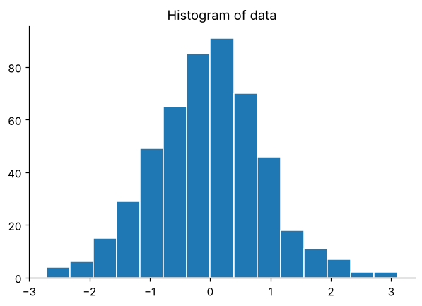

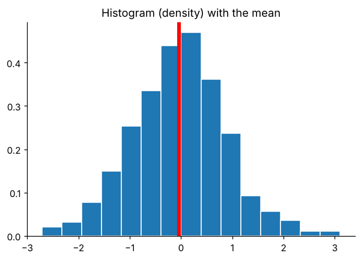

Now a boxplot:

```
plt.boxplot(data)
plt.axhline(data.mean(), color="blue", linewidth=2)  # horizontal line at the mean
plt.title("Creative Title")
plt.ylabel("A y-axis label (with units)")
plt.show()
```

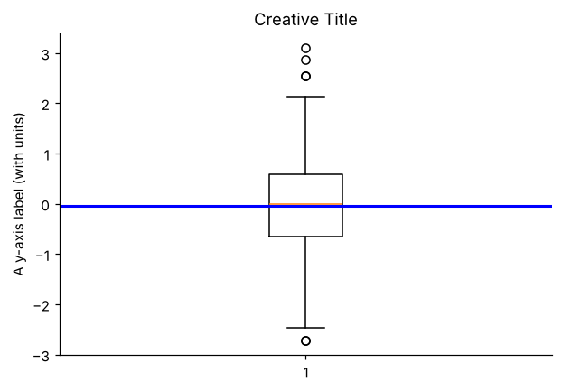

Now let us generate some data for scatter and line plots.

```
x = np.arange(1, 101)
y = x * 2

plt.scatter(x, y)  # scatter plot
plt.show()

# again, but fancier
plt.scatter(x, y, marker="D", s=30, color="purple")  # marker shape, size, and color
plt.title("Scatter plot")
plt.xlabel("Predictor (x)")
plt.ylabel("Response (y)")
plt.show()

# this looks better as a line plot
plt.plot(x, y, color="purple")
plt.title("Line plot")
plt.xlabel("Predictor (x)")
plt.ylabel("Response (y)")
plt.show()
```

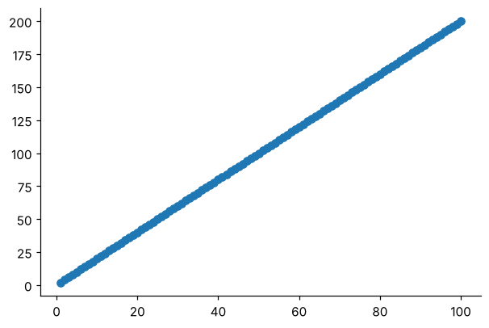

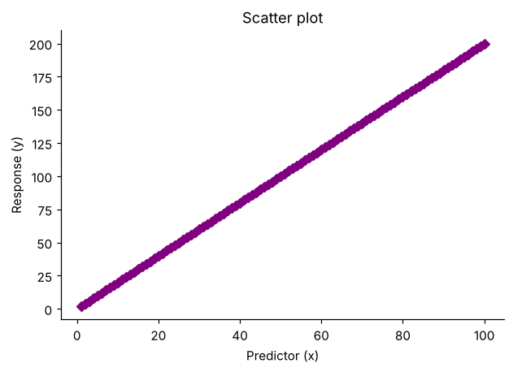

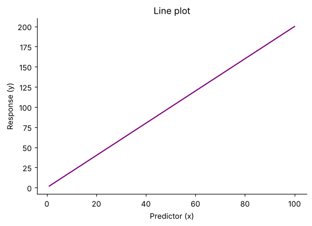

### 7.2 Plotting Functions

```
x = np.arange(0, 10.01, 0.01)
y1 = 2 * x + 1                 # y1 = 2x + 1
y2 = 2 * x**2 + 3 * x + 1      # y2 = 2x^2 + 3x + 1
y3 = x**3 + 2 * x**2 - 3       # y3 = x^3 + 2x^2 - 3

plt.plot(x, y1, color="blue");   plt.title("y1 = 2x + 1");           plt.show()
plt.plot(x, y2, color="purple"); plt.title("y2 = 2x^2 + 3x + 1");    plt.show()
plt.plot(x, y3, color="red");    plt.title("y3 = x^3 + 2x^2 - 3");   plt.show()
```

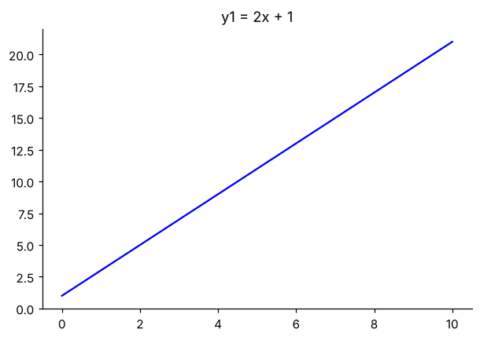

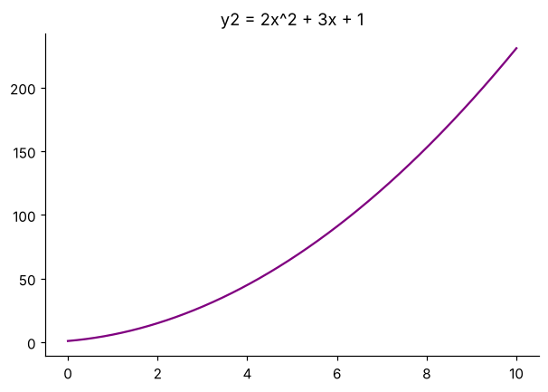

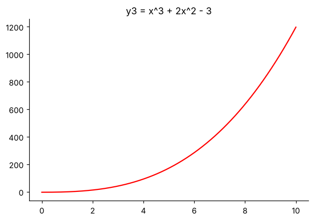

### 7.3 Multiple Graphs

```
fig, ax = plt.subplots(figsize=(7, 4.5))
ax.plot(x, y1, color="purple", linewidth=3, label="Linear")
ax.plot(x, y2, color="blue", linewidth=3, label="Quadratic")
ax.plot(x, y3, color="red", linewidth=3, label="Polynomial")
ax.set_xlim(0, 10)
ax.set_ylim(-10, 50)
ax.set_title("Figure. Graph of functions")
ax.set_xlabel("x")
ax.set_ylabel("y")
ax.legend(loc="upper right", ncol=2)
plt.show()

# set_title: title of the graph      set_xlabel / set_ylabel: axis labels
# color: line color                  linewidth: line width
# set_xlim / set_ylim: axis limits   legend: adds the legend
```

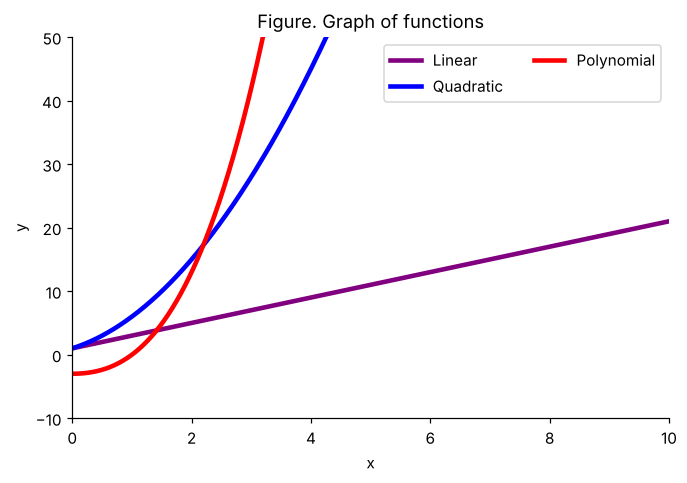

### 7.4 Export High Quality Figures

Higher resolution (dpi) means sharper figures but bigger files.

```
fig.savefig("Figure_functions.png", dpi=300, bbox_inches="tight")  # PNG
fig.savefig("Figure_functions.pdf", bbox_inches="tight")           # PDF
# fig.savefig("Figure_functions.tiff", dpi=1200)                   # TIFF, very large file
print("Saved:", [f for f in os.listdir() if f.startswith("Figure_functions")])
```

```
Saved: ['Figure_functions.pdf', 'Figure_functions.png']
```

### 7.5 Bar Charts

Bar charts compare values across categories, such as revenue per acre by crop:

```
crop_names = ["Corn", "Soybeans", "Wheat", "Sorghum"]
revenue_acre = [180 * 4.25, 55 * 10.90, 50 * 5.60, 95 * 4.05]

plt.bar(crop_names, revenue_acre, color=["#2a5298", "#3c8d5a", "#c9a227", "#a0522d"])
plt.ylabel("Revenue ($ per acre)")
plt.title("Revenue per acre by crop")
plt.show()
```

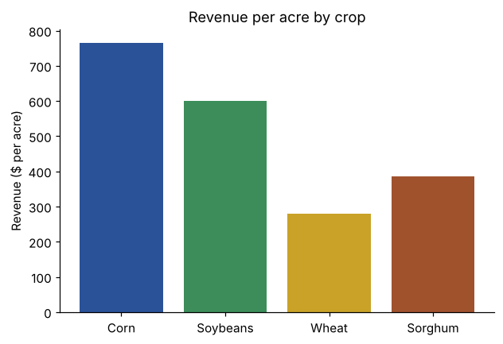

### 7.6 Supply and Demand

Let us plot linear demand $Q_d = 100 - 8P$ and supply $Q_s = 20 + 12P$, then mark the market equilibrium where $Q_d = Q_s$:

```
P = np.linspace(0, 10, 100)
Qd = 100 - 8 * P
Qs = 20 + 12 * P

p_eq = (100 - 20) / (8 + 12)   # solve 100 - 8P = 20 + 12P
q_eq = 100 - 8 * p_eq
print(f"Equilibrium price: {p_eq:.2f}, quantity: {q_eq:.2f}")

plt.plot(Qd, P, label="Demand", color="#2a5298", linewidth=2)
plt.plot(Qs, P, label="Supply", color="#c0392b", linewidth=2)
plt.scatter([q_eq], [p_eq], color="black", zorder=3)
plt.annotate(f"Equilibrium ({q_eq:.0f}, {p_eq:.2f})", (q_eq, p_eq), textcoords="offset points", xytext=(10, -15))
plt.xlabel("Quantity")
plt.ylabel("Price")
plt.xlim(0, 110)
plt.ylim(0, 10)
plt.legend()
plt.title("Market equilibrium")
plt.show()
```

```
Equilibrium price: 4.00, quantity: 68.00
```

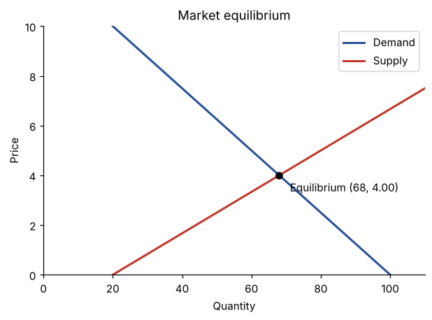

### 7.7 Mapping with Python

For maps we use **plotly**, which draws interactive maps of US states without downloading any boundary files. The values below are **randomly generated** for practice. Run these cells in Google Colab, or install plotly first with `pip install plotly`.

Run in Google Colab or after installing the packages

```
import plotly.express as px

states = ["NE", "KS", "OK", "TX", "LA", "MO", "AR", "IA", "MN", "WI", "IL", "MI", "IN"]
rng = np.random.default_rng(123)
state_data = pd.DataFrame({
    "state": states,
    "value": rng.integers(1000, 100000, len(states)),  # example values
})

fig = px.choropleth(state_data, locations="state", locationmode="USA-states",
                    color="value", scope="usa", color_continuous_scale="Greens",
                    title="Selected US States (example data)")
fig.show()
```

County-level maps, like the Kansas map in the R notes, need county boundary files. The **geopandas** package can read the US Census cartographic boundary files directly from the web:

Run in Google Colab or after installing the packages

```
# !pip install geopandas
import geopandas as gpd

url = "https://www2.census.gov/geo/tiger/GENZ2023/shp/cb_2023_us_county_20m.zip"
counties = gpd.read_file(url)
kansas = counties[counties["STATEFP"] == "20"]  # 20 is the FIPS code for Kansas

ax = kansas.plot(column="AWATER", cmap="Blues", edgecolor="black", legend=True, figsize=(9, 5))
ax.set_title("Water Area at County Level in Kansas")
ax.set_axis_off()
plt.show()
```

## 8 Regression and Summary Tables

We use **statsmodels**, the standard Python package for regressions. It is already installed in Google Colab; elsewhere install it with `pip install statsmodels`. To keep the example self-contained, we first simulate a small farm dataset.

```
rng = np.random.default_rng(42)
n = 200
farms = pd.DataFrame({
    "fertilizer": rng.uniform(50, 200, n),   # lbs of nitrogen per acre
    "rainfall": rng.uniform(15, 40, n),      # inches during the season
    "irrigated": rng.integers(0, 2, n),      # 1 if the field is irrigated
})
farms["yield_bu"] = (60 + 0.35 * farms["fertilizer"] + 1.5 * farms["rainfall"]
                     + 20 * farms["irrigated"] + rng.normal(0, 15, n))  # corn yield, bu/acre
farms["high_yield"] = (farms["yield_bu"] > 160).astype(int)             # 1 if yield > 160
farms.describe().round(2)
```

|  | fertilizer | rainfall | irrigated | yield_bu | high_yield |
| --- | --- | --- | --- | --- | --- |
| count | 200.00 | 200.00 | 200.00 | 200.00 | 200.00 |
| mean | 124.08 | 27.48 | 0.52 | 153.68 | 0.40 |
| std | 42.35 | 7.21 | 0.50 | 25.70 | 0.49 |
| min | 51.10 | 15.31 | 0.00 | 78.13 | 0.00 |
| 25% | 87.83 | 20.92 | 0.00 | 137.34 | 0.00 |
| 50% | 121.85 | 27.64 | 1.00 | 153.46 | 0.00 |
| 75% | 162.09 | 34.16 | 1.00 | 170.44 | 1.00 |
| max | 198.86 | 39.67 | 1.00 | 213.63 | 1.00 |

### 8.1 Regression with Matrix Algebra

Before using a regression package, it helps to see what it does. The OLS coefficients solve $\hat\beta = (X'X)^{-1}X'y$, which we can compute with the matrix tools from earlier:

```
X = np.column_stack([np.ones(n), farms[["fertilizer", "rainfall", "irrigated"]]])  # add an intercept column
y = farms["yield_bu"].to_numpy()

beta = np.linalg.solve(X.T @ X, X.T @ y)  # solves (X'X) b = X'y
pd.Series(beta, index=["Intercept", "fertilizer", "rainfall", "irrigated"]).round(3)
```

```
Intercept     59.386
fertilizer     0.336
rainfall       1.598
irrigated     16.820
dtype: float64
```

The estimates are close to the values we used to simulate the data (0.35, 1.5, and 20). They are not exact because of the random noise we added, which is exactly what happens with real data.

### 8.2 Linear Regression

Run in Google Colab or after installing the packages

```
import statsmodels.formula.api as smf

lm1 = smf.ols("yield_bu ~ fertilizer", data=farms).fit()  # Model 1
print(lm1.summary())
```

### 8.3 Multiple Linear Regression and Probit

Run in Google Colab or after installing the packages

```
linear1 = smf.ols("yield_bu ~ fertilizer + rainfall + irrigated", data=farms).fit()
linear2 = smf.ols("yield_bu ~ fertilizer + rainfall", data=farms).fit()
probit = smf.probit("high_yield ~ fertilizer + rainfall + irrigated", data=farms).fit()

# A side-by-side summary table, similar to stargazer in R
from statsmodels.iolib.summary2 import summary_col
table = summary_col([linear1, linear2, probit],
                    model_names=["OLS (1)", "OLS (2)", "Probit"],
                    stars=True, float_format="%.3f")
print(table)

# Save the table as an HTML file you can open in Word
with open("regression_table.html", "w") as f:
    f.write(table.as_html())
```